# Customer Status Prediction Report

Omar Mohamed , Munther Moufeed , Hamdo Alhasan

26-12-2025

# Introduction

**Project Objective**: The primary goal of this report is to develop a robust machine learning model capable of predicting a customer’s **Status** (e.g., Current, Churned, etc.). By leveraging a comprehensive dataset tailored to customer behavior, we aim to provide actionable insights for retention strategies.

**The Data**: We integrate **9 distinct data sources** to build a 360-degree view of the customer. These include:

- **Demographics & Firmographics**: Region, Industry Vertical, and Company Size.
- **Financials**: Monthly Recurring Revenue (MRR) and Revenue History.
- **Engagement**: Newsletter interactions, Product Bug reports, and Support Ticket activity.
- **Sentiment**: Direct feedback from Customer Satisfaction surveys.

**The Method**: We employ a rigorous pipeline from Data Integration and Feature Engineering to training advanced ensembles like **Random Forest** and **Gradient Boosting (GBM)** to solve this multiclass classification problem.

# Phase 1: Data Integration

We have 18 files in total: 9 for training and 9 for testing. We will load and merge them based on a common key.

## 1. Data Loading

We load the raw datasets for both training and testing.

```r
library(tidyverse)
library(knitr)
library(kableExtra)
library(corrplot)
library(caret)

data_path <- "./data"

# --- Load Training Data ---
train_demo <- read.csv(file.path(data_path, "customer_demographics_train.csv"), stringsAsFactors = FALSE)
train_mrr <- read.csv(file.path(data_path, "customer_monthly_recurring_revenue_train.csv"), stringsAsFactors = FALSE)
train_region <- read.csv(file.path(data_path, "customer_region_and_industry_train.csv"), stringsAsFactors = FALSE)
train_rev_hist <- read.csv(file.path(data_path, "customer_revenue_history_train.csv"), stringsAsFactors = FALSE)
train_status <- read.csv(file.path(data_path, "customer_status_level_train.csv"), stringsAsFactors = FALSE)
train_newsletter <- read.csv(file.path(data_path, "newsletter_engagement_train.csv"), stringsAsFactors = FALSE)
train_bug_reports <- read.csv(file.path(data_path, "product_bug_reports_train.csv"), stringsAsFactors = FALSE)
train_support <- read.csv(file.path(data_path, "support_ticket_activity_train.csv"), stringsAsFactors = FALSE)
train_sat_scores <- read.csv(file.path(data_path, "customer_satisfaction_scores_train.csv"), stringsAsFactors = FALSE)

# --- Load Test Data ---
test_demo <- read.csv(file.path(data_path, "customer_demographics_test.csv"), stringsAsFactors = FALSE)
test_mrr <- read.csv(file.path(data_path, "customer_monthly_recurring_revenue_test.csv"), stringsAsFactors = FALSE)
test_region <- read.csv(file.path(data_path, "customer_region_and_industry_test.csv"), stringsAsFactors = FALSE)
test_rev_hist <- read.csv(file.path(data_path, "customer_revenue_history_test.csv"), stringsAsFactors = FALSE)
test_status <- read.csv(file.path(data_path, "customer_status_level_test.csv"), stringsAsFactors = FALSE)
test_newsletter <- read.csv(file.path(data_path, "newsletter_engagement_test.csv"), stringsAsFactors = FALSE)
test_bug_reports <- read.csv(file.path(data_path, "product_bug_reports_test.csv"), stringsAsFactors = FALSE)
test_support <- read.csv(file.path(data_path, "support_ticket_activity_test.csv"), stringsAsFactors = FALSE)
test_sat_scores <- read.csv(file.path(data_path, "customer_satisfaction_scores_test.csv"), stringsAsFactors = FALSE)
```

## 2. Data Standardization & Merging

**Strategy & Reasoning**:

1. **One-Row-Per-Customer**: Our goal is to predict the status of a *single customer*. However, source tables (like Satisfaction Scores or Bug Reports) often have multiple entries per customer (e.g., 3 surveys in a year). We must **aggregate** these into a single row to avoid duplicates.
2. **Aggregation Logic**:
   - **Numeric Scores**: We take the **Mean** (Average). This captures the customer’s *overall* sentiment over time.
   - **Counts**: We take the **Sum**. A customer who filed 5 bugs in Jan and 5 in Feb has 10 total bugs.
3. **Early Type Conversion**: We convert Likert scale ratings (1-10) to numeric *before* aggregation to allow for averaging.
   - *Note*: For text-based fields like `Understanding` or `Frequency`, we preserve the raw text (taking the maximum/most recent value) so we can apply specific scoring logic in **Phase 3 (Feature Engineering)**.
4. **Dropping Noise**: Columns like `Year` and `Quarter` are removed. Averaging “2022” and “2023” to get “2022.5” is meaningless. We rely on **Recency** instead.

```r
# 1. Standardize ID
if ("CUS.ID" %in% names(train_demo)) {
    train_demo <- train_demo %>% rename(Customer.ID = CUS.ID)
}

# 2. Aggregate Satisfaction Scores
if (!is.null(train_sat_scores)) {
    # Ensure Ratings are Numeric (Fixing User Issue)
    # We explicitly convert the Likert scale columns to numeric
    # AND Map text-based columns ('Understanding', 'Frequency') to numeric scales
    train_sat_scores <- train_sat_scores %>%
        mutate(across(c(
            contains("recommend"),
            contains("value.you.gain"),
            contains("quality"),
            contains("usability")
        ), ~ suppressWarnings(as.numeric(.)))) %>%
        # Remove irrelevant Year/Quarter
        select(-Year, -Quarter)

    train_sat_agg <- train_sat_scores %>%
        group_by(Customer.ID) %>%
        summarise(
            across(where(is.numeric), \(x) mean(x, na.rm = TRUE)),
            across(where(is.character), \(x) max(x, na.rm = TRUE)) # Placeholder aggregation for strings/dates
        )
} else {
    train_sat_agg <- NULL
}

# Aggregate Bug Reports (Found duplicates in source)
train_bug_agg <- train_bug_reports %>%
    group_by(Customer.ID) %>%
    summarise(Product.Bug.Task.Count = sum(Product.Bug.Task.Count, na.rm = TRUE))

# 3. Merge
train_master <- train_demo %>%
    left_join(train_mrr, by = "Customer.ID") %>%
    left_join(train_region, by = "Customer.ID") %>%
    left_join(train_rev_hist, by = "Customer.ID")

if (!is.null(train_sat_agg)) {
    train_master <- train_master %>% left_join(train_sat_agg, by = "Customer.ID")
}

train_master <- train_master %>%
    left_join(train_status, by = "Customer.ID") %>%
    left_join(train_newsletter, by = "Customer.ID") %>%
    left_join(train_bug_agg, by = "Customer.ID") %>%
    left_join(train_support, by = "Customer.ID") %>%
    # Fill NAs for Counts
    mutate(
        Product.Bug.Task.Count = replace_na(Product.Bug.Task.Count, 0),
        Company.Newsletter.Interaction.Count = replace_na(Company.Newsletter.Interaction.Count, 0),
        Help.Ticket.Count = replace_na(Help.Ticket.Count, 0)
    )
```

```r
dim(train_master)
```

```
## [1] 2068   21
```

We perform the same standardization and merging for the Test set.

```r
# 1. Standardize ID
if ("CUS.ID" %in% names(test_demo)) {
    test_demo <- test_demo %>% rename(Customer.ID = CUS.ID)
}

# 2. Aggregate Satisfaction Scores
# Ensure Ratings are Numeric
test_sat_scores <- test_sat_scores %>%
    mutate(across(c(
        contains("recommend"),
        contains("value.you.gain"),
        contains("quality"),
        contains("usability")
    ), ~ suppressWarnings(as.numeric(.)))) %>%
    # Remove irrelevant Year/Quarter
    select(-Year, -Quarter)

test_sat_agg <- test_sat_scores %>%
    group_by(Customer.ID) %>%
    summarise(
        across(where(is.numeric), \(x) mean(x, na.rm = TRUE)),
        across(where(is.character), \(x) max(x, na.rm = TRUE))
    )

# Aggregate Bug Reports (Test file has duplicates)
test_bug_agg <- test_bug_reports %>%
    group_by(Customer.ID) %>%
    summarise(Product.Bug.Task.Count = sum(Product.Bug.Task.Count, na.rm = TRUE))

# 3. Merge
test_master <- test_demo %>%
    left_join(test_mrr, by = "Customer.ID") %>%
    left_join(test_region, by = "Customer.ID") %>%
    left_join(test_rev_hist, by = "Customer.ID") %>%
    left_join(test_sat_agg, by = "Customer.ID") %>%
    left_join(test_status, by = "Customer.ID") %>%
    left_join(test_newsletter, by = "Customer.ID") %>%
    left_join(test_bug_agg, by = "Customer.ID") %>%
    left_join(test_support, by = "Customer.ID") %>%
    # Fill NAs
    mutate(
        Help.Ticket.Count = replace_na(Help.Ticket.Count, 0),
        Product.Bug.Task.Count = replace_na(Product.Bug.Task.Count, 0),
        Company.Newsletter.Interaction.Count = replace_na(Company.Newsletter.Interaction.Count, 0)
    )

# Check Dimensions
dim(test_master)
```

```
## [1] 619  21
```

## 3. Data Cleaning & Type Conversion

Some financial columns contain special characters (‘$’, ‘,’) and are read as characters. We clean and convert them to numeric types immediately after merging.

```r
# Define a helper to clean currency
clean_currency <- function(x) {
    as.numeric(gsub("[\\$,]", "", x))
}

# Apply to Training Data
train_master <- train_master %>%
    mutate(
        MRR = clean_currency(MRR),
        Total.Revenue = clean_currency(Total.Revenue)
    )

# Apply to Test Data
test_master <- test_master %>%
    mutate(
        MRR = clean_currency(MRR),
        Total.Revenue = clean_currency(Total.Revenue)
    )

# Verify conversion
str(train_master[c("MRR", "Total.Revenue")])
```

```
## 'data.frame':    2068 obs. of  2 variables:
##  $ MRR          : num  196 3714 NA 14297 2250 ...
##  $ Total.Revenue: num  NA NA NA 732199 0 ...
```

## 4. Initial Consistency Checks

```r
# Preview Data
head(train_master) %>%
    kbl(caption = "Preview of Training Data") %>%
    kable_styling(bootstrap_options = "striped", full_width = F) %>%
    scroll_box(height = "400px", width = "100%")
```

Preview of Training Data

| Customer.ID | Customer.Age..Months. | MRR | Region | Vertical | Subvertical | Total.Revenue | How.likely.are.you.to.recommend.insider.to.a.friend.or.colleague | How.would.you.rate.the.value.you.gain.from.our.company | Please.rate.the.overall.quality.of.our.products | Please.rate.the.usability.of.the.panel | Survey.Date | Response.Date | How.frequently.are.you.using.our.platform | Please.rate.your.understanding.of.our.reporting.capabilities.in.the.panel | Status | Customer.Level | Company.Newsletter.Interaction.Count | Product.Bug.Task.Count | Help.Ticket.Count | Help.Ticket.Lead.Time..hours. |
| --- | --- | --- | --- | --- | --- | --- | --- | --- | --- | --- | --- | --- | --- | --- | --- | --- | --- | --- | --- | --- |
| CUS-1471650 | 24 | 196 | Malaysia | Media and Publishing | Content Websites | NA | NA | NA | NA | NA | NA | NA | NA | NA | Onboarding | Enterprise | 0 | 0 | 0 | NA |
| CUS-1087300 | 25 | 3714 | Australia | Transportation and Logistics | Transportation and Logistics | NA | NA | NA | NA | NA | NA | NA | NA | NA | Churn | Semi-Enterprise | 0 | 0 | 0 | NA |
| CUS-230550 | 12 | NA | Turkey | Retail | Fashion Retailer | NA | NA | NA | NA | NA | NA | NA | NA | NA | Churn | Long-tail | 0 | 0 | 0 | NA |
| CUS-1470950 | 22 | 14297 | Thailand | Retail | Marketplace | 732199 | 7.333333 | 4.0 | 3.833333 | 3.833333 | 2022-07-01 | 2022-09-30 | Once a Week | I tried but could not find everything I need | Retained | Enterprise | 3 | 863 | 30 | 366 |
| CUS-1526100 | 11 | 2250 | Vietnam | Other | Other | 0 | 9.000000 | 4.5 | 4.500000 | 3.750000 | 2022-07-01 | 2022-09-30 | Once a Week | I need someone from Insider team to provide me the report from the panel | Retained | Semi-Enterprise | 2 | 551 | 4 | 1206 |
| CUS-1507900 | 12 | NA | Vietnam | Other | Other | NA | NA | NA | NA | NA | NA | NA | NA | NA | Churn | Long-tail | 1 | 0 | 7 | 486 |

# Phase 2: Exploratory Data Analysis (EDA)

In this phase, we analyze the structure of the data, the distribution of the target variable, and relationships between features.

## 1. Target Variable Distribution

We examine `customer_status_level` (specifically the `Status` column) to identify any class imbalance.

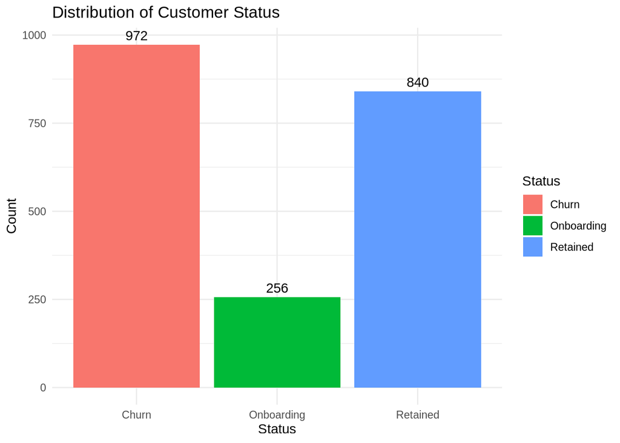

```r
# Standardize Status column name if needed (renaming logic confirms we have 'Status')
# Check distribution
if ("Status" %in% names(train_master)) {
    proportions <- table(train_master$Status) %>% prop.table()

    table(train_master$Status) %>%
        kbl(caption = "Target Variable Distribution") %>%
        kable_styling(bootstrap_options = "striped", full_width = F)

    # Visualizing Imbalance
    ggplot(train_master, aes(x = Status, fill = Status)) +
        geom_bar() +
        geom_text(stat = "count", aes(label = after_stat(count)), vjust = -0.5) +
        labs(title = "Distribution of Customer Status", x = "Status", y = "Count") +
        theme_minimal()
} else {
    message("Status column not found for EDA.")
}
```

**Insight:** This plot shows the balance of our target classes. An unequal distribution (class imbalance) means we should be careful with accuracy metrics and may need resampling techniques (like SMOTE) during training.

## 2. Univariate Analysis (Numerical Features)

We look at the distribution of key numerical metrics like MRR and Total Revenue.

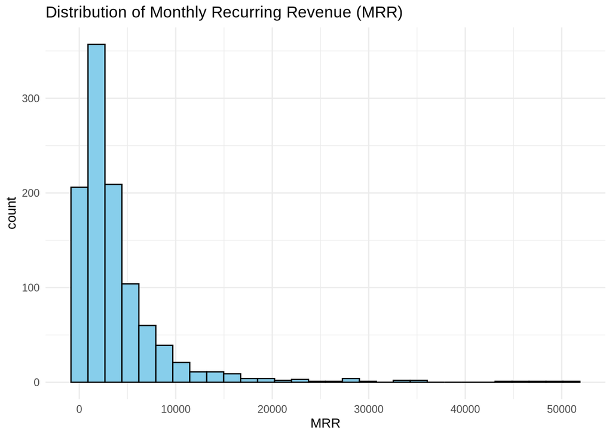

```r
# Select numeric columns
numeric_cols <- train_master %>%
    select_if(is.numeric) %>%
    names()

# 1. MRR Distribution
if ("MRR" %in% names(train_master)) {
    ggplot(data.frame(MRR_val = train_master$MRR), aes(x = MRR_val)) +
        geom_histogram(bins = 30, fill = "skyblue", color = "black") +
        labs(title = "Distribution of Monthly Recurring Revenue (MRR)", x = "MRR") +
        theme_minimal()
}
```

**Insight:** The frequency distribution of MRR shows how revenue is distributed across the customer base. A right-skewed plot (long tail to the right) is common, indicating many small customers and fewer high-value ones.

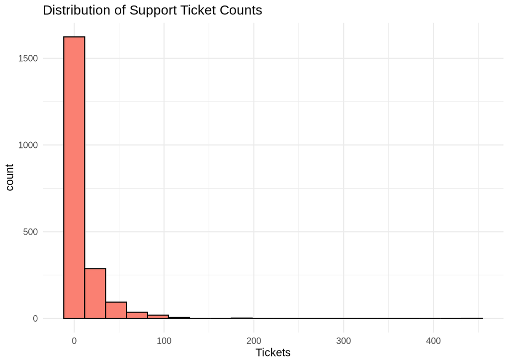

```r
# 2. Ticket Count Distribution
if ("Help.Ticket.Count" %in% names(train_master)) {
    ggplot(train_master, aes(x = Help.Ticket.Count)) +
        geom_histogram(bins = 20, fill = "salmon", color = "black") +
        labs(title = "Distribution of Support Ticket Counts", x = "Tickets") +
        theme_minimal()
}
```

**Insight:** This histogram reveals the volume of support interactions. A concentration at zero suggests most customers are trouble-free, while high outliers represent customers needing intensive support.

## 3. Bivariate Analysis

We explore relationships between features, such as MRR vs. Status.

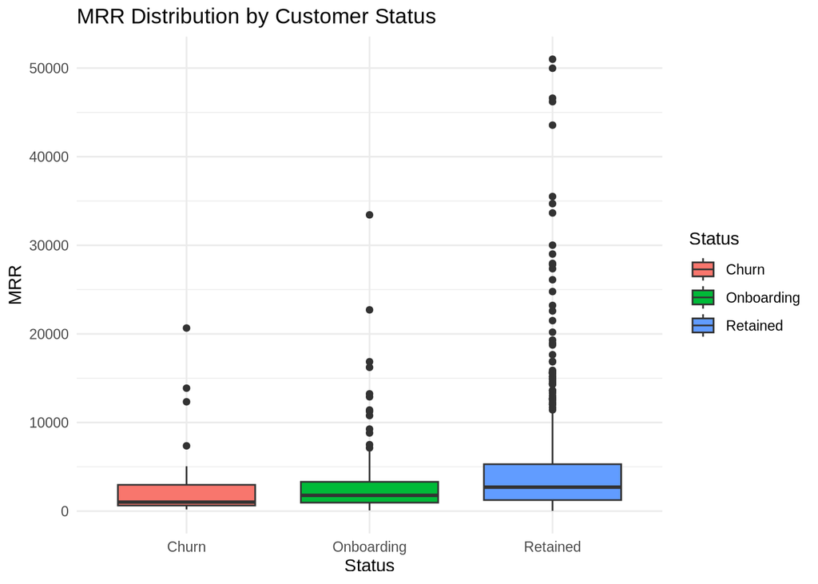

```r
if ("Status" %in% names(train_master) && "MRR" %in% names(train_master)) {
    # Temp clean for plot
    df_plot <- train_master %>%
        mutate(MRR_plot = if (is.character(MRR)) as.numeric(gsub("[\\$,]", "", MRR)) else MRR)

    # MRR by Status
    ggplot(df_plot, aes(x = Status, y = MRR_plot, fill = Status)) +
        geom_boxplot() +
        labs(title = "MRR Distribution by Customer Status", y = "MRR") +
        theme_minimal()
}
```

**Insight:** This boxplot compares the revenue range for each customer status. If ‘Retained’ customers show a higher median MRR than ‘Churned’ ones, it confirms that higher-paying customers are generally more stable (or vice versa).

# Phase 3: Preprocessing & Feature Engineering

We prepare the data for modeling by handling missing values, encoding categorical variables, and selecting features.

## 1. Missing Value Analysis & Imputation

First, we identify which columns have missing data.

```r
# Calculate missing percentage per column
missing_vals <- colSums(is.na(train_master))
missing_df <- data.frame(Column = names(missing_vals), Missing_Count = missing_vals) %>%
    filter(Missing_Count > 0) %>%
    mutate(Percentage = round((Missing_Count / nrow(train_master)) * 100, 2)) %>%
    arrange(desc(Percentage))

missing_df %>%
    kbl(caption = "Missing Values Summary", row.names = FALSE) %>%
    kable_styling(bootstrap_options = "striped")
```

Missing Values Summary

| Column | Missing_Count | Percentage |
| --- | --- | --- |
| Please.rate.the.usability.of.the.panel | 1570 | 75.92 |
| How.likely.are.you.to.recommend.insider.to.a.friend.or.colleague | 1566 | 75.73 |
| How.would.you.rate.the.value.you.gain.from.our.company | 1566 | 75.73 |
| Please.rate.the.overall.quality.of.our.products | 1566 | 75.73 |
| Survey.Date | 1566 | 75.73 |
| Response.Date | 1566 | 75.73 |
| How.frequently.are.you.using.our.platform | 1566 | 75.73 |
| Please.rate.your.understanding.of.our.reporting.capabilities.in.the.panel | 1566 | 75.73 |
| Total.Revenue | 1356 | 65.57 |
| MRR | 1012 | 48.94 |
| Help.Ticket.Lead.Time..hours. | 996 | 48.16 |

**Strategy & Reasoning**:

- **Numeric Imputation (Median)**: We use the **Median** instead of the Mean because financial data (like MRR) often has outliers. The Mean is easily skewed by one “Wait” customer, whereas the Median represents the “typical” customer more accurately.
- **Categorical Imputation (Mode)**: For missing categories, we impute the **Mode** (most frequent value) to preserve the underlying probability distribution of the data.

```r
# Define Mode function
get_mode <- function(v) {
    uniqv <- unique(na.omit(v))
    uniqv[which.max(tabulate(match(v, uniqv)))]
}

# Apply Imputation
train_clean <- train_master %>%
    mutate(across(where(is.numeric), ~ ifelse(is.na(.), median(., na.rm = TRUE), .))) %>%
    mutate(across(where(is.character), ~ ifelse(is.na(.), get_mode(.), .)))

# Verify no missing left
sum(is.na(train_clean))
```

```
## [1] 0
```

## 2. Feature Engineering

We create new features to capture more complex patterns and stronger logic in the data:

- **`Customer_Level_Score` (Ordinal)**: We mapped “Long-tail” (1), “Semi-Enterprise” (2), and “Enterprise” (3) to numbers. This preserves the **order** and magnitude of importance, whereas treating them as simple factors would lose this hierarchy.
- **`Days_Since_Last_Feedback` (Recency)**: We replaced raw dates (which ML models struggle with) with a “Recency” metric. A high number here indicates “Silent Churn” risk.
- **`Bug_vs_Interaction_Ratio`**: High bug counts are bad, but *worse* if the customer isn’t engaging with us elsewhere. This ratio isolates “High Friction, Low Value” interactions.
- **`Log_MRR`**: Log-transformed Revenue to handle skewness.
- **`Tenure_Years`**: Converting Age in Months to Years for interpretability.
- **`Total_Interactions`**: A holistic measure of volume.
- **`Platform_Usage_Freq`**: Mapped from text (“Daily” -> 30) to give the model a sense of magnitude.

**`High-Cardinality Factors`**: `Vertical` (23 levels), `Subvertical` (51 levels), and `Region` (24 levels) are lumped into “Top 10” categories + “Other” to reduce model complexity and improve speed.

```r
# Analysis Reference Date (Max Date in Training)
analysis_date <- max(as.Date(train_clean$Survey.Date), na.rm = TRUE)

train_eng <- train_clean %>%
    mutate(
        # 1. Log Transformation for skewed MRR
        Log_MRR = log1p(MRR),

        # 2. Customer Tenure (Approximate from Age in Months)
        Tenure_Years = Customer.Age..Months. / 12,

        # 3. Total Interactions (Engagement Volume)
        Total_Interactions = Company.Newsletter.Interaction.Count +
            Product.Bug.Task.Count +
            Help.Ticket.Count,

        # 4. Average Ticket Resolution Time
        Avg_Ticket_Time = ifelse(Help.Ticket.Count > 0,
            Help.Ticket.Lead.Time..hours. / Help.Ticket.Count,
            0
        ),

        # 5. NEW: Customer Level Ordinal Encoding (Size/Importance)
        Customer_Level_Score = case_when(
            Customer.Level == "Enterprise" ~ 3,
            Customer.Level == "Semi-Enterprise" ~ 2,
            Customer.Level == "Long-tail" ~ 1,
            TRUE ~ 1 # Default to lowest if missing
        ),

        # 6. NEW: Recency (Days since last survey response)
        # Measures "Silent Churn" risk
        Days_Since_Last_Feedback = as.numeric(difftime(analysis_date, as.Date(Survey.Date), units = "days")),

        # 7. NEW: Bug vs. Interaction Ratio
        # High bugs with low newsletter engagement = High Risk
        Bug_vs_Interaction_Ratio = Product.Bug.Task.Count / (Company.Newsletter.Interaction.Count + 1),

        # 8. NEW: Understanding Score (Text -> Ordinal 0-5)
        Understanding_Score = case_when(
            str_detect(Please.rate.your.understanding.of.our.reporting.capabilities.in.the.panel, "easily") ~ 5,
            str_detect(Please.rate.your.understanding.of.our.reporting.capabilities.in.the.panel, "pull all") ~ 4,
            str_detect(Please.rate.your.understanding.of.our.reporting.capabilities.in.the.panel, "could not find") ~ 2,
            str_detect(Please.rate.your.understanding.of.our.reporting.capabilities.in.the.panel, "need someone") ~ 1,
            str_detect(Please.rate.your.understanding.of.our.reporting.capabilities.in.the.panel, "don't use") ~ 0,
            TRUE ~ 0
        ),

        # 9. NEW: Platform Usage Frequency (Text -> Days per Month)
        Platform_Usage_Freq = case_when(
            str_detect(How.frequently.are.you.using.our.platform, "Day") ~ 30,
            str_detect(How.frequently.are.you.using.our.platform, "Week") ~ 4,
            str_detect(How.frequently.are.you.using.our.platform, "Month") ~ 1,
            TRUE ~ 0
        ),

        # 10. Factor Lumping
        Vertical = fct_lump_n(Vertical, n = 10, other_level = "Other"),
        Subvertical = fct_lump_n(Subvertical, n = 10, other_level = "Other"),
        Region = fct_lump_n(Region, n = 10, other_level = "Other")
    ) %>%
    # Drop original columns to prevent multicollinearity and reduce dimensionality
    # Removed: MRR (Log_MRR used), Age (Tenure used), Lead Time (Avg used)
    # Removed: Level (Score used), Dates (Recency used)
    # Removed: Long Text Columns (Scores used)
    select(
        -MRR, -Customer.Age..Months., -Help.Ticket.Lead.Time..hours.,
        -Customer.Level, -Survey.Date, -Response.Date,
        -Please.rate.your.understanding.of.our.reporting.capabilities.in.the.panel,
        -How.frequently.are.you.using.our.platform
    )


# Verify Factor Lumping
# Check number of levels for modified columns
sapply(train_eng[c("Vertical", "Subvertical", "Region")], function(x) length(unique(x))) %>%
    kbl(caption = "Factor Levels after Lumping") %>%
    kable_styling(bootstrap_options = "striped", full_width = F)
```

Factor Levels after Lumping

|  | x |
| --- | --- |
| Vertical | 10 |
| Subvertical | 10 |
| Region | 11 |